# Univariate Plots Section

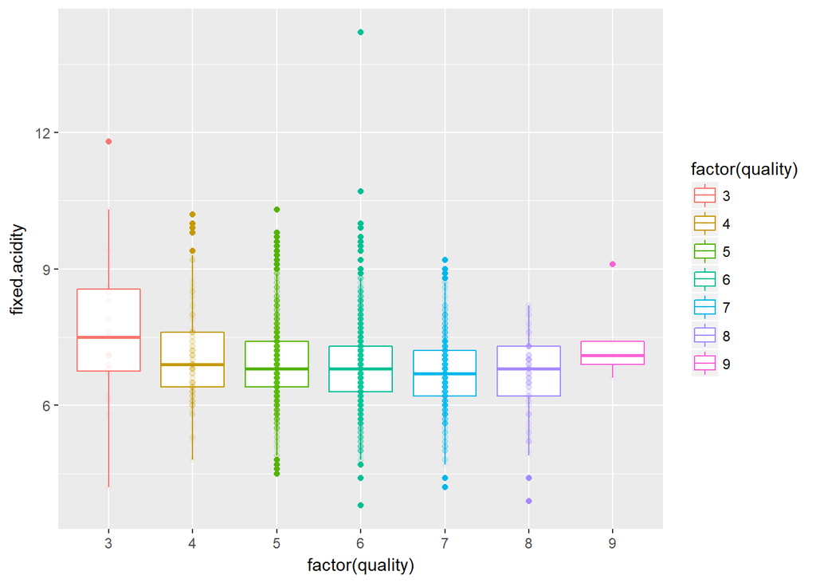

It seems that for medium to high quality the fixed acidity is close to constant. Only the lowe quality wines have an increase in fixed acidity and a large spread of data.

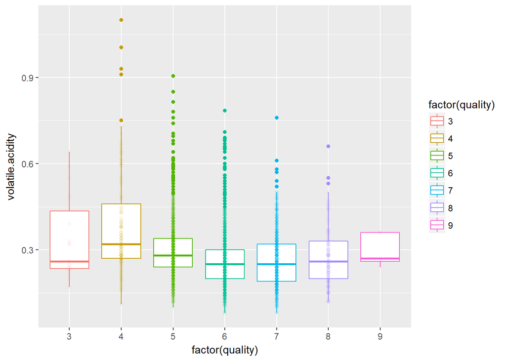

The volatile acidity is high for low and high quality wines. The lowest volatice acidity is found for the medium quality white wines.

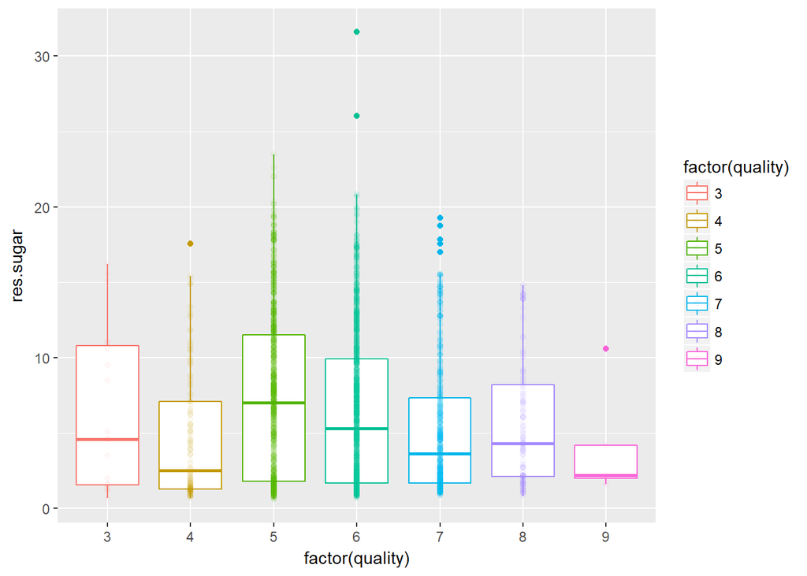

The lowest value of residual sugar seems to be rather constant for all qualities but the highest values varies with quality. Most of the datasets are skewed.

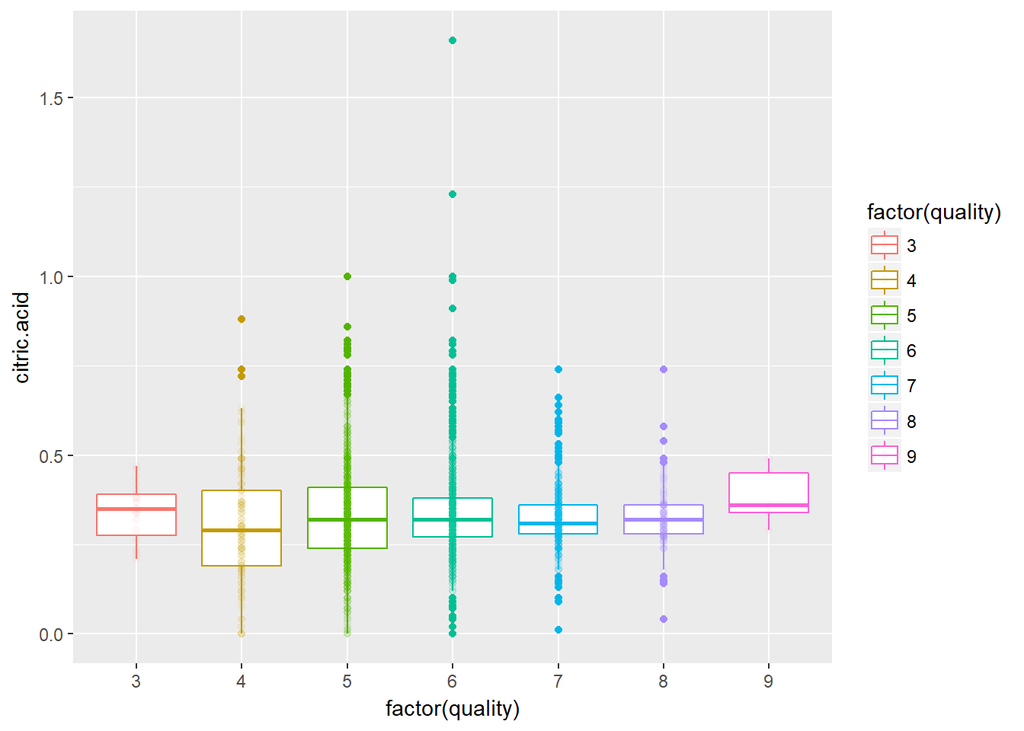

The quality does not seem to vary a lot with the citric acidic values. The highest quality wines seems to have more citric acid.

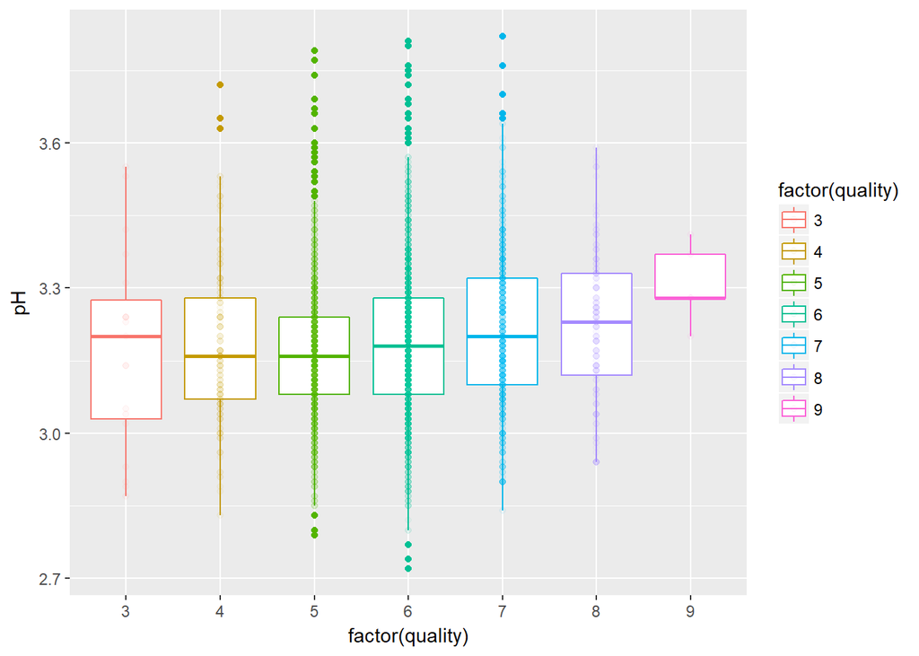

It could seem that an increasing pH could mean a higher quality wine, however the low quality wines also has a high pH. pH alone is not an indicator of quality.

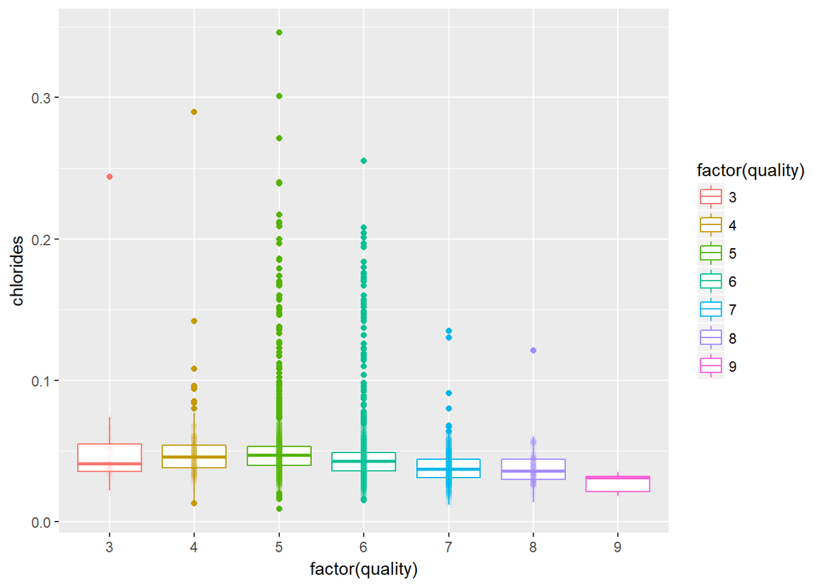

For the cholride content the quartiles in the boxplot are very narrow in range with a large range of outliers. The median trend is for high quality wines to have a low content of chlorides and the outliers seems to narrow in as well.

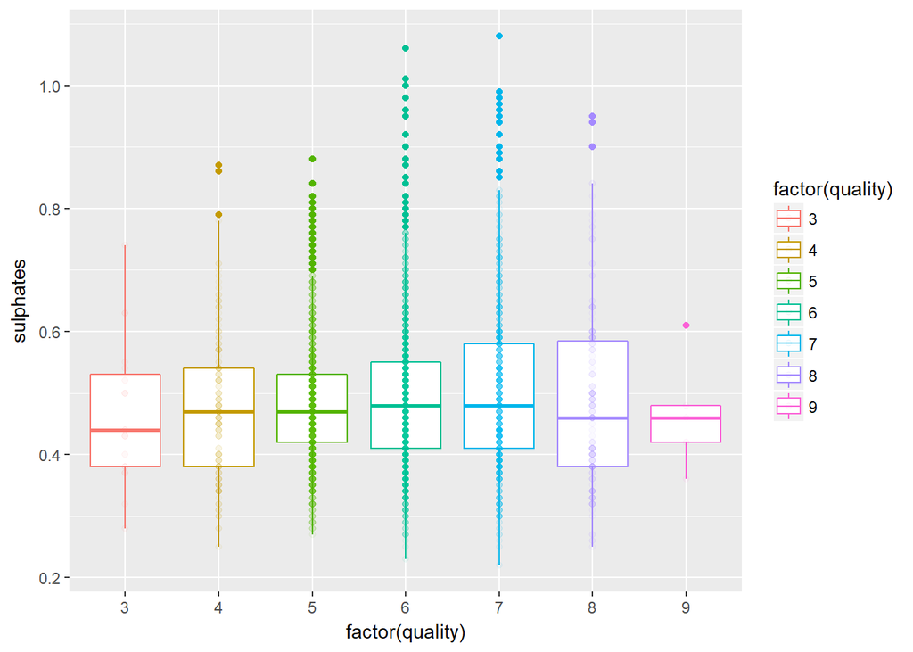

The median for sulphatesshows a nearly constant trend and does not seem to have a major impact on the quality of the wine.

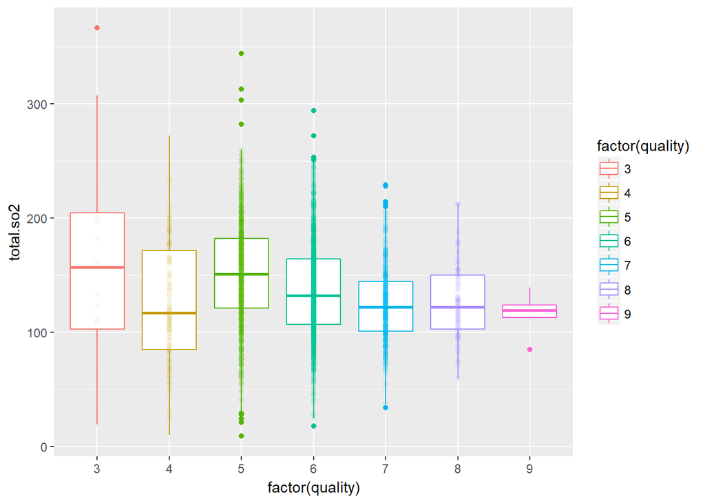

There seems to be a trend of decreasing total sulfur dioxide for higher quality wines.

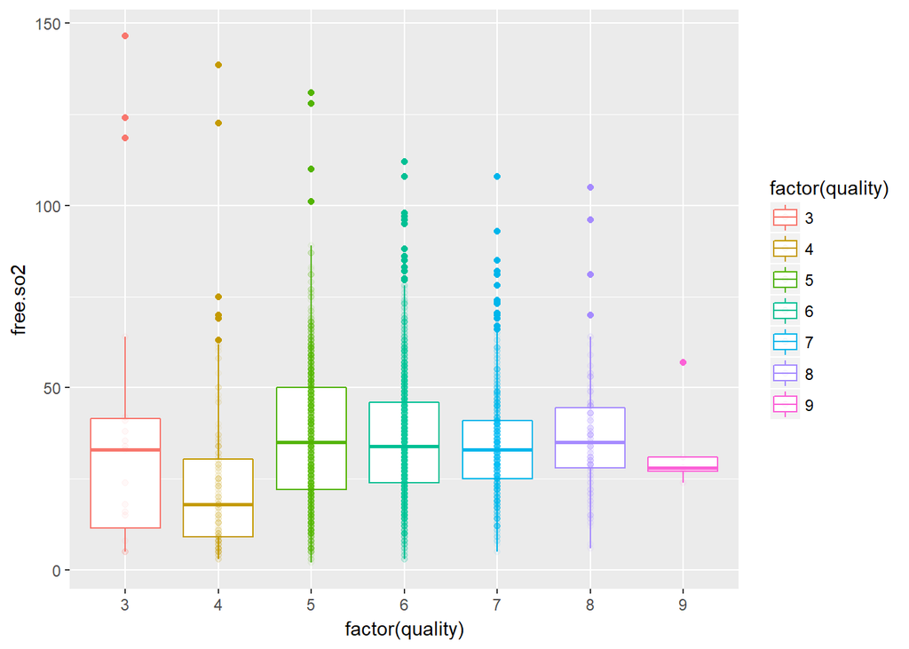

Both low and high quality wines have a low amount of free sulfur dioxide. This makes it difficult to identify the wine quality from this parameter.

# Bivariate Analysis

### Talk about some of the relationships you observed in this part of the investigation. How did the feature(s) of interest vary with other features in the dataset?

This dataset seems to only contain a limited amount of very high and very low quality wines but many more in the middle. This results in a lower spread of the variables when investigating the low and high quality wines, whereas a larger spread in the data is seen for the ratings in between.  
For some of the variables, it seems that they are converging on a very limited range for a high quality wine, e.g. when looking at the pH. This small range of high quality might not represent the truth due to the limited amount of high quality wines in the dataset.  
Most of the datasets plotted against quality, showed either an increasing or decreasing trend to the best quality. However in most of them, the lowest quality wines usually also showed the same trend as the high quality wines, which makes it difficult to properly identify the best wines from these physical parameters.

### Did you observe any interesting relationships between the other features (not the main feature(s) of interest)?

There seems to be a strong relationship between alcohol and both residual sugar and density. The density was expected, as alcohol has a lower density than water, hence increasing the alcohol will decrease the wines density.  
Another expected correlation was between citric acid and the pH level, as pH will decrease when more acid is present.

### What was the strongest relationship you found?

Two strong relationships were found. The density and alcohol content has a Pearson correlation coefficient of -0.80 and residual sugar and density has a Pearson correlation coefficient of 0.83.  
Density is clearly influenced by both the alcohol content and residual sugar. Increasing the alcohol content will lower the density, as it is lighter than water. Increasing the residual sugar increases the density.

# Multivariate Plots Section

To ease the comparison between the qualities of wine, they will be collected into three groups:  
Low quality: <= 5  
Medium quality: 6-7  
High quality: => 8

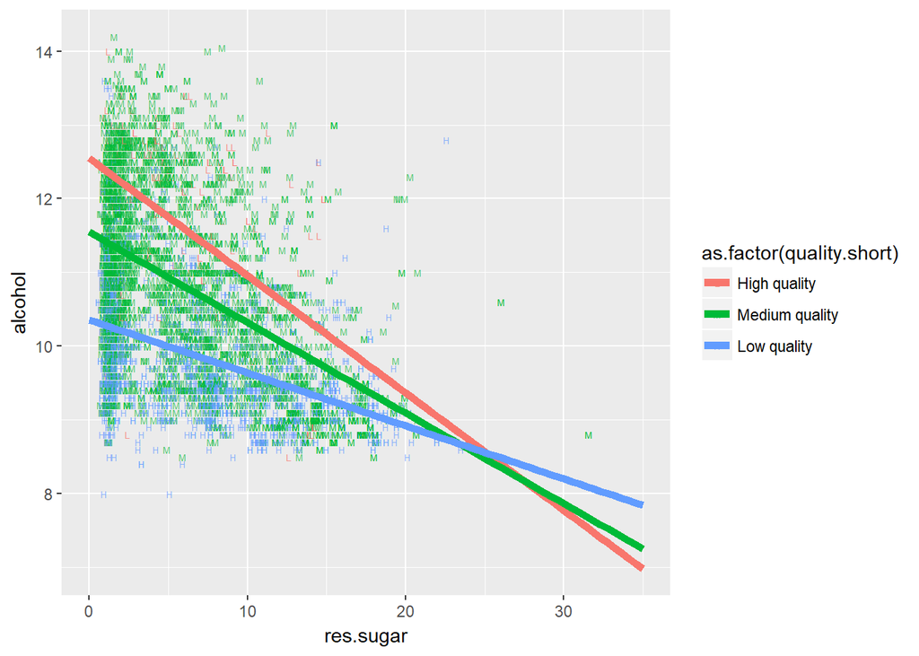

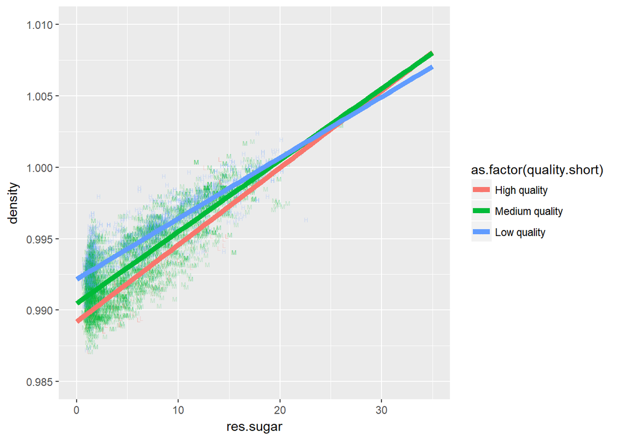

The first plot, shows the relationship between residual sugar and alcohol. The three lines are showing the low, medium and high quality wines. It is quite evident, that the higher alcohol content, the higher quality. All 3 lines almost intersects in the same place, but this is outside the data range and does not seem to be valid.  
The second plot, shows the relationship between residual sugar and density The three lines are showing the low, medium and high quality wines. For this plot, the order of the lines have been reversed. High quality wines have a low density and low quality wines have a high density - this is again related to alcohol.

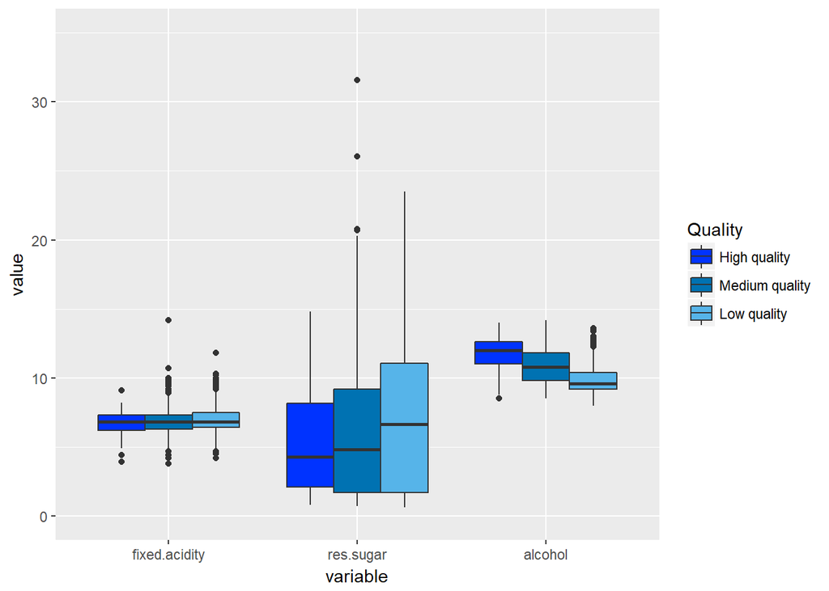

The median for ficed acidity seems to increase slightly for decreasing quality, whereas it is opposite for alcohol. For residual sugar, the level is almost the same for high and medium quality wines, where low quality wines have a much higher median.

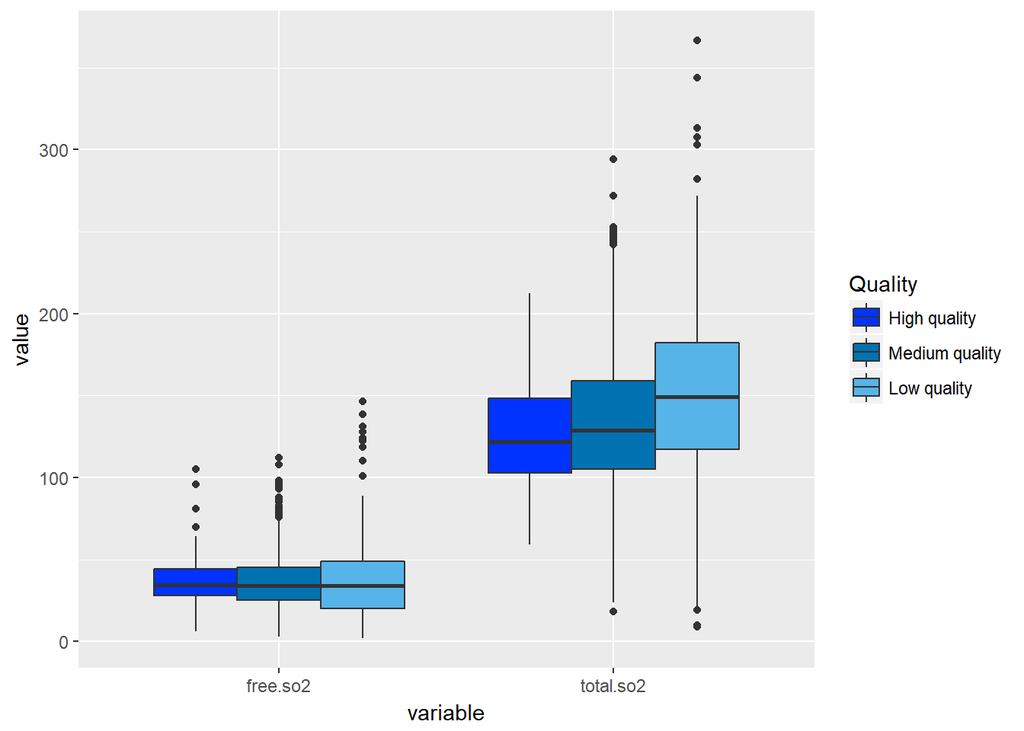

The free sulfur dioxide content does not seem to influence the quality, but the lower total sulfur dioxide the better quality.

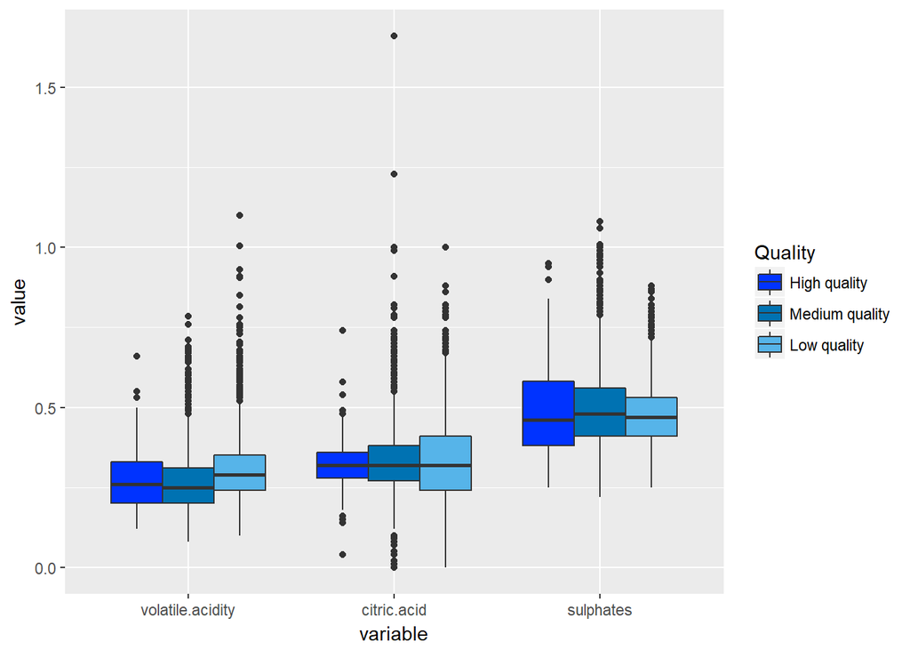

Acidity, citric acid and sulphates does not seem to have a large influence on the quality of the wines as the medians are almost constant across the qualities.

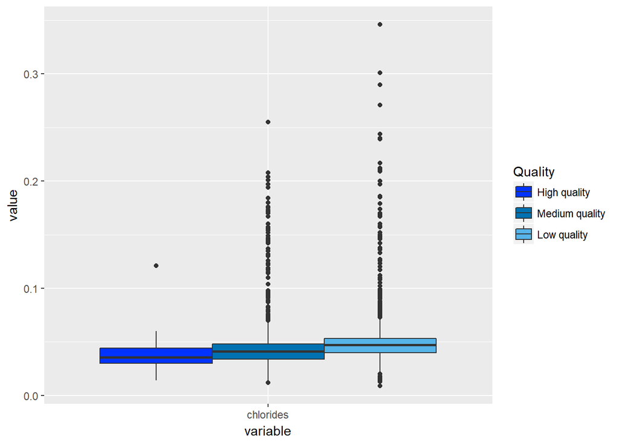

It could seem that the for lower chlorides you get a the better quality wine.

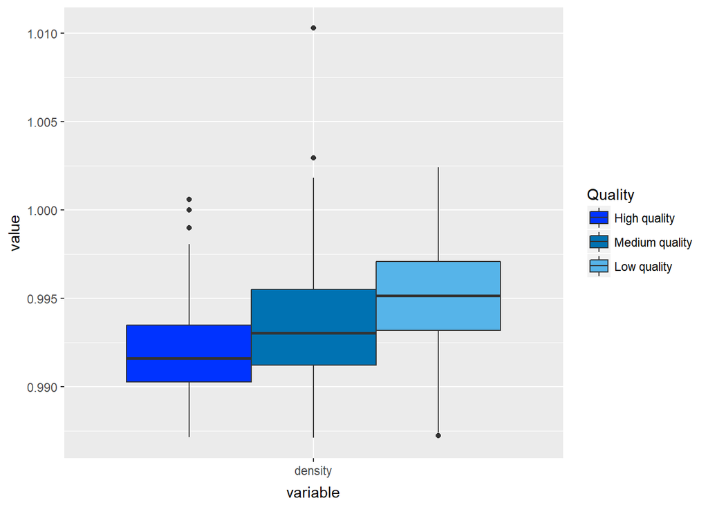

The lower density the higher quality. This is the reverse from alcohol as seen earlier and is expected due to the physical dependency between the two.

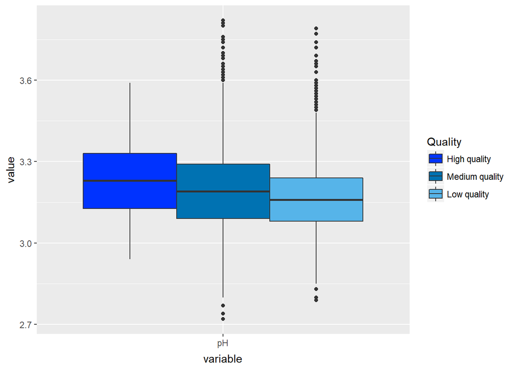

This plot indicated that for a higher pH you get a better quality white wine.

# Multivariate Analysis

### Talk about some of the relationships you observed in this part of the investigation. Were there features that strengthened each other in terms of looking at your feature(s) of interest?

Some of the relationships between the different variables and quality, that was investigated in the bivariate section, has become more clear. E.g. the alcohol vs sectioned quality only indicates higher quality with increasing alcohol, although the plot in the bivariate section showed a slight increase in alcohol for low quality wines. This is due to the sectioning of quality into low, medium and high quality.  
This sectioning could remove some trends, e.g. the tendency that was seen in bivariate analysis with high and low quality wines showing the same behaviors.

### Were there any interesting or surprising interactions between features?

**I would have assumed that citric acidity, volatile acidity and sulphates would have had a larger influence on the perception of the quality of white wine. From this investigation, it does not seem that these variables have a significant influence and other parameters are of much more interest.**

# Final Plots and Summary

### Plot One

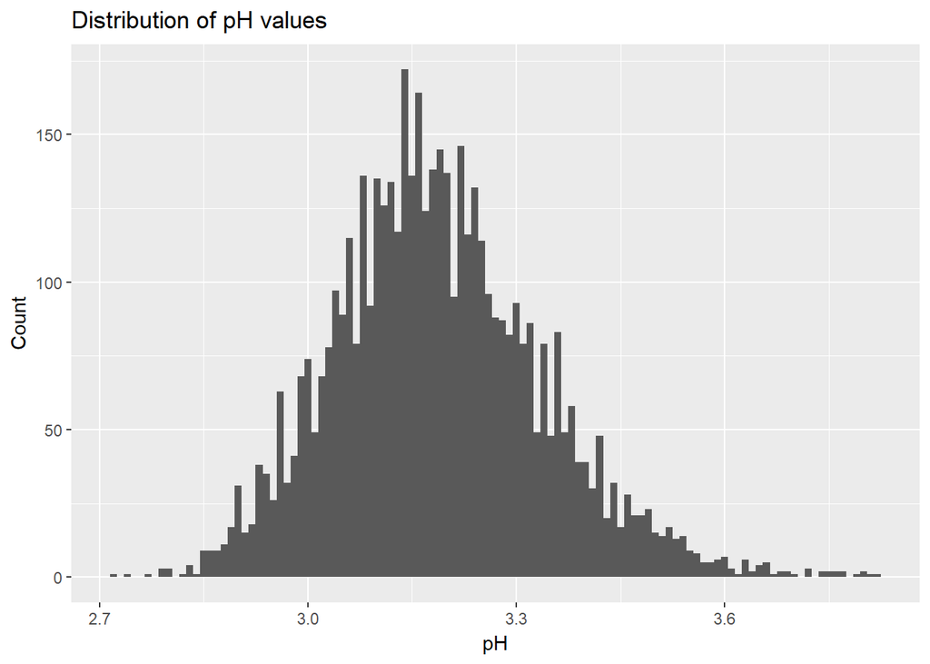

```
## [1] "The pH median is 3.2 and the mean is 3.2"
```

### Description One

**The pH variable is a nice example of a normal distribution with the mean equal to the median indicating no skew.**

### Plot Two

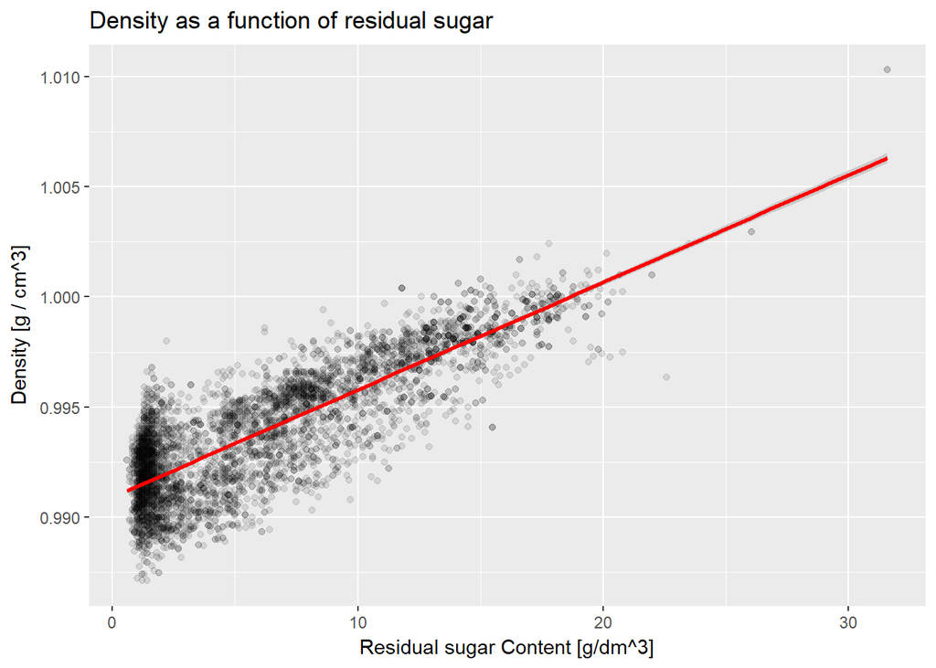

```
## [1] "Pearsons Correlation Coefficient: 0.833975"
```

### Description Two

**There is a strong positive correlation between density and the residual sugar. This makes sense as increasing the sugar content of the wine will increase the density.**

### Plot Three

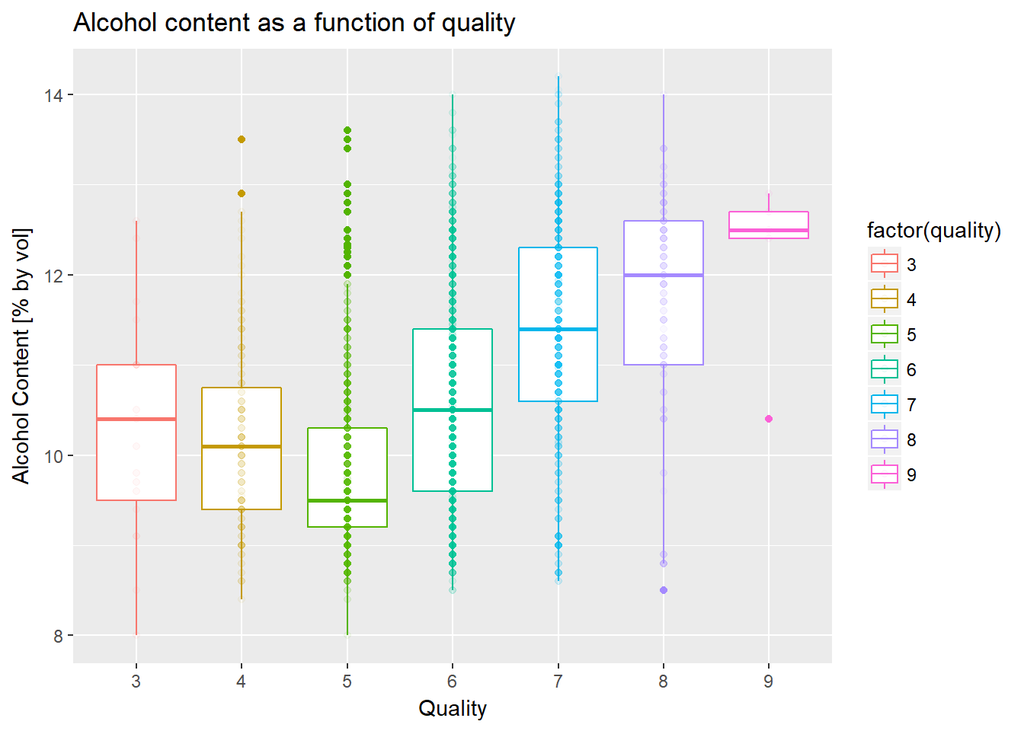

### Description Three

**The data seems to indicate that you should look for a high alcohol content and preferably above 12% in order to get a nice white wine. Interestingly you could be tricked when choosing a white wine with an alcohol content of ~10.5%, as it could have a quality rating of both 3 and 6.**

# Reflection

It is surprising that citric acid, sulphates and volatile acidity does not seem to have a big influence on the quality of white wines, whereas alcohol and density seems to be the most important factors. Density is closely correlated to alcohol content and residual sugar as these two impacts the density of the wine. From all the parameters a high alcohol content is the key indicator for a good quality white wine.  
This evaluation builds on physical parameters of white wine and some quality value. According to the dataset, the quality parameter has been established using “sensory data”. Wine taste and quality are very subjective and will most likely vary from person to person, which is why this quality parameter can be hard to trust. To test some of the conclusions from this dataset a blind tasting with a large group of people could be used to verify the conclusions.  
One of the struggles with this dataset has been to identify the correlations between the variables and finding the greatest indicators of a high quality white wine. After identifying relationships and correlations I have spent a great deal of time contemplating how to show the data and which plots and R functions that could be utilized.